# Predict fish phenology: advanced

Morgan Sparks, Bryan M. Maitland

## Overview

The function `predict_phenolgy()` is purposefully kept fairly simple so it can be expanded to iterate across datasets. Typically, this will take the form of loops or vectorizing in R (functions of the `map()` family from **purrr** and `apply()` family from **base**). There are many reasons why you might want to iterate, including predicting over multiple years, multiple sites, predicting hatch or emergence simultaneously, or even using multiple potential spawn dates. We’ll show some examples below (moving from less to more complicated). First, we load packages:

```r
library(hatchR) # for data and phenology modeling
library(ggplot2) # for additional plotting options
library(purrr) # for iteration
library(lubridate) # for date manipulation
library(tibble) # for data manipulation
library(dplyr) # for data manipulation
library(tidyr) # for data manipulation
```

## Multiple spawn dates

Given the example we used in the Predict Phenology-Basic vignette, perhaps we now want to expand it to predict multiple spawn dates (e.g., the early, peak, and late part of the spawning distribution) for the Woody Island population in Lake Iliamna. Using Table 1 from Sparks et al. (2019) we see that the spawning range is between August 14 and September 3rd, with the peak occurring August 18th. We can set these dates up as a vector to run the model over.

```r
WI_spawn_dates <- c("1990-08-14", "1990-08-18", "1990-09-3")
```

The we will go through the typical process of getting the model parameterized as we did previously.

```r
sockeye_hatch_mod <- model_select(
  author = "Beacham and Murray 1990",
  species = "sockeye",
  model_id = 2,
  development_type = "hatch"
)
```

Now we can automate the model. We’ll demonstrate two ways—a loop and a vectorized approach.

### Looping

```r
# Loop storage objects
OUT_loop_all <- NULL
OUT_loop_d2h <- NULL

# Loop body
for (d in 1:length(WI_spawn_dates)) { # d will be our numerical iterator

  # subset the element d of the vector and assign to object
  WI_spawn <- WI_spawn_dates[d]

  # predict phenology
  WI_hatch <- predict_phenology(
    data = woody_island,
    dates = date,
    temperature = temp_c,
    spawn.date = WI_spawn,
    model = sockeye_hatch_mod
  )

  ### ALL output ###
  # do this if we want to maintain all info predict_phenology
  OUT_loop_all[[d]] <- WI_hatch

  ### A single element of output ###
  # alternatively, subsets out output
  temp <- tibble(matrix(data = NA, ncol = 2, nrow = 1)) # empty dataframe to add in data
  colnames(temp) <- c("spawn_date", "days_2_hatch") # change column names
  temp$spawn_date <- WI_spawn # assign spawn date
  temp$days_2_hatch <- WI_hatch$days_to_develop # assign days to hatch
  OUT_loop_d2h <- rbind(OUT_loop_d2h, temp) # row bind temp object and OUT object
}
```

Inspect the loop output:

```r
glimpse(OUT_loop_all)
```

```
#> List of 3
#>  $ :List of 4
#>   ..$ days_to_develop: int 71
#>   ..$ dev_period     :'data.frame':  1 obs. of  2 variables:
#>   .. ..$ start: Date[1:1], format: "1990-08-14"
#>   .. ..$ stop : Date[1:1], format: "1990-10-23"
#>   ..$ ef_table       : tibble [71 × 5] (S3: tbl_df/tbl/data.frame)
#>   ..$ model_specs    : spc_tbl_ [1 × 5] (S3: spec_tbl_df/tbl_df/tbl/data.frame)
#>   .. ..- attr(*, "spec")=
#>   .. .. .. cols(
#>   .. .. ..   author = col_character(),
#>   .. .. ..   species = col_character(),
#>   .. .. ..   model_id = col_character(),
#>   .. .. ..   development_type = col_character(),
#>   .. .. ..   expression = col_character()
#>   .. .. .. )
#>   .. ..- attr(*, "problems")=<externalptr>
#>  $ :List of 4
#>   ..$ days_to_develop: int 74
#>   ..$ dev_period     :'data.frame':  1 obs. of  2 variables:
#>   .. ..$ start: Date[1:1], format: "1990-08-18"
#>   .. ..$ stop : Date[1:1], format: "1990-10-30"
#>   ..$ ef_table       : tibble [74 × 5] (S3: tbl_df/tbl/data.frame)
#>   ..$ model_specs    : spc_tbl_ [1 × 5] (S3: spec_tbl_df/tbl_df/tbl/data.frame)
#>   .. ..- attr(*, "spec")=
#>   .. .. .. cols(
#>   .. .. ..   author = col_character(),
#>   .. .. ..   species = col_character(),
#>   .. .. ..   model_id = col_character(),
#>   .. .. ..   development_type = col_character(),
#>   .. .. ..   expression = col_character()
#>   .. .. .. )
#>   .. ..- attr(*, "problems")=<externalptr>
#>  $ :List of 4
#>   ..$ days_to_develop: int 110
#>   ..$ dev_period     :'data.frame':  1 obs. of  2 variables:
#>   .. ..$ start: Date[1:1], format: "1990-09-03"
#>   .. ..$ stop : Date[1:1], format: "1990-12-21"
#>   ..$ ef_table       : tibble [110 × 5] (S3: tbl_df/tbl/data.frame)
#>   ..$ model_specs    : spc_tbl_ [1 × 5] (S3: spec_tbl_df/tbl_df/tbl/data.frame)
#>   .. ..- attr(*, "spec")=
#>   .. .. .. cols(
#>   .. .. ..   author = col_character(),
#>   .. .. ..   species = col_character(),
#>   .. .. ..   model_id = col_character(),
#>   .. .. ..   development_type = col_character(),
#>   .. .. ..   expression = col_character()
#>   .. .. .. )
#>   .. ..- attr(*, "problems")=<externalptr>
```

You can also see we made a tibble of dates and predicted days to hatch:

```r
OUT_loop_d2h
```

```
#> # A tibble: 3 × 2
#>   spawn_date days_2_hatch
#>   <chr>             <int>
#> 1 1990-08-14           71
#> 2 1990-08-18           74
#> 3 1990-09-3           110
```

If you don’t want the full output of each run of `predict_phenolgy()` and you just for example want the predicted days to hatch, then it’s easier to access those elements within the loop as demonstrated with the `temp` object section demonstrated in the loop.

### Vectorizing

#### Mapping

Vectorizing, while historically about prioritizing speed, is now more about making your code more readable (see Chapter 26 in [R for Data Science](https://r4ds.hadley.nz/iteration) and chapter 9 in [Advanced R](https://adv-r.hadley.nz/functionals.html)).

We’ll demonstrate using `purrr::map()`. If you are unfamiliar with mapping but want to learn more about how it works and it’s power, we highly recommend the linked chapters from R for Data Science and Advanced R.

```r
# map works by applying a function over a list (our vector is a very simple list)
# if you are familiar with apply() functions, map is essentially the same

results_map <- map(
  WI_spawn_dates, # vector we are mapping over
  predict_phenology, # function we are mapping with (note no "()"),
  data = woody_island, # additional arguments required by predict_phenology
  dates = date,
  temperature = temp_c,
  model = sockeye_hatch_mod
)

# we now have a list of lists the same as OUT_loop_all
glimpse(results_map)
```

```
#> List of 3
#>  $ :List of 4
#>   ..$ days_to_develop: int 71
#>   ..$ dev_period     :'data.frame':  1 obs. of  2 variables:
#>   .. ..$ start: Date[1:1], format: "1990-08-14"
#>   .. ..$ stop : Date[1:1], format: "1990-10-23"
#>   ..$ ef_table       : tibble [71 × 5] (S3: tbl_df/tbl/data.frame)
#>   ..$ model_specs    : spc_tbl_ [1 × 5] (S3: spec_tbl_df/tbl_df/tbl/data.frame)
#>   .. ..- attr(*, "spec")=
#>   .. .. .. cols(
#>   .. .. ..   author = col_character(),
#>   .. .. ..   species = col_character(),
#>   .. .. ..   model_id = col_character(),
#>   .. .. ..   development_type = col_character(),
#>   .. .. ..   expression = col_character()
#>   .. .. .. )
#>   .. ..- attr(*, "problems")=<externalptr>
#>  $ :List of 4
#>   ..$ days_to_develop: int 74
#>   ..$ dev_period     :'data.frame':  1 obs. of  2 variables:
#>   .. ..$ start: Date[1:1], format: "1990-08-18"
#>   .. ..$ stop : Date[1:1], format: "1990-10-30"
#>   ..$ ef_table       : tibble [74 × 5] (S3: tbl_df/tbl/data.frame)
#>   ..$ model_specs    : spc_tbl_ [1 × 5] (S3: spec_tbl_df/tbl_df/tbl/data.frame)
#>   .. ..- attr(*, "spec")=
#>   .. .. .. cols(
#>   .. .. ..   author = col_character(),
#>   .. .. ..   species = col_character(),
#>   .. .. ..   model_id = col_character(),
#>   .. .. ..   development_type = col_character(),
#>   .. .. ..   expression = col_character()
#>   .. .. .. )
#>   .. ..- attr(*, "problems")=<externalptr>
#>  $ :List of 4
#>   ..$ days_to_develop: int 110
#>   ..$ dev_period     :'data.frame':  1 obs. of  2 variables:
#>   .. ..$ start: Date[1:1], format: "1990-09-03"
#>   .. ..$ stop : Date[1:1], format: "1990-12-21"
#>   ..$ ef_table       : tibble [110 × 5] (S3: tbl_df/tbl/data.frame)
#>   ..$ model_specs    : spc_tbl_ [1 × 5] (S3: spec_tbl_df/tbl_df/tbl/data.frame)
#>   .. ..- attr(*, "spec")=
#>   .. .. .. cols(
#>   .. .. ..   author = col_character(),
#>   .. .. ..   species = col_character(),
#>   .. .. ..   model_id = col_character(),
#>   .. .. ..   development_type = col_character(),
#>   .. .. ..   expression = col_character()
#>   .. .. .. )
#>   .. ..- attr(*, "problems")=<externalptr>
```

```r
# we can then access days to hatch easily as such
results_map |> map_dbl("days_to_develop")
```

```
#> [1]  71  74 110
```

#### Apply

While **tidyverse** packages like **purrr** have become quite popular, the base functionality of R has long had a set of functions to do similar things as map. They are called the apply family. Because **hatchR** is built using much of the functionality of the tidyverse we opt for using `purrr:::map()` over `apply()` functions, however we will demonstrate a similar workflow as above using the apply family.

```r
# lapply() is the equivalent function as map() in the apply family
# they both output lists

results_lapply <- lapply(WI_spawn_dates, # vector we are mapping over
  predict_phenology, # function we are mapping with (note no "()"),
  data = woody_island, # additional arguments required by predict phenology
  dates = date,
  temperature = temp_c,
  model = sockeye_hatch_mod
)
```

You can see that `lapply()` and `purrr::map()` output the same results:

```r
glimpse(results_lapply)
```

```
#> List of 3
#>  $ :List of 4
#>   ..$ days_to_develop: int 71
#>   ..$ dev_period     :'data.frame':  1 obs. of  2 variables:
#>   .. ..$ start: Date[1:1], format: "1990-08-14"
#>   .. ..$ stop : Date[1:1], format: "1990-10-23"
#>   ..$ ef_table       : tibble [71 × 5] (S3: tbl_df/tbl/data.frame)
#>   ..$ model_specs    : spc_tbl_ [1 × 5] (S3: spec_tbl_df/tbl_df/tbl/data.frame)
#>   .. ..- attr(*, "spec")=
#>   .. .. .. cols(
#>   .. .. ..   author = col_character(),
#>   .. .. ..   species = col_character(),
#>   .. .. ..   model_id = col_character(),
#>   .. .. ..   development_type = col_character(),
#>   .. .. ..   expression = col_character()
#>   .. .. .. )
#>   .. ..- attr(*, "problems")=<externalptr>
#>  $ :List of 4
#>   ..$ days_to_develop: int 74
#>   ..$ dev_period     :'data.frame':  1 obs. of  2 variables:
#>   .. ..$ start: Date[1:1], format: "1990-08-18"
#>   .. ..$ stop : Date[1:1], format: "1990-10-30"
#>   ..$ ef_table       : tibble [74 × 5] (S3: tbl_df/tbl/data.frame)
#>   ..$ model_specs    : spc_tbl_ [1 × 5] (S3: spec_tbl_df/tbl_df/tbl/data.frame)
#>   .. ..- attr(*, "spec")=
#>   .. .. .. cols(
#>   .. .. ..   author = col_character(),
#>   .. .. ..   species = col_character(),
#>   .. .. ..   model_id = col_character(),
#>   .. .. ..   development_type = col_character(),
#>   .. .. ..   expression = col_character()
#>   .. .. .. )
#>   .. ..- attr(*, "problems")=<externalptr>
#>  $ :List of 4
#>   ..$ days_to_develop: int 110
#>   ..$ dev_period     :'data.frame':  1 obs. of  2 variables:
#>   .. ..$ start: Date[1:1], format: "1990-09-03"
#>   .. ..$ stop : Date[1:1], format: "1990-12-21"
#>   ..$ ef_table       : tibble [110 × 5] (S3: tbl_df/tbl/data.frame)
#>   ..$ model_specs    : spc_tbl_ [1 × 5] (S3: spec_tbl_df/tbl_df/tbl/data.frame)
#>   .. ..- attr(*, "spec")=
#>   .. .. .. cols(
#>   .. .. ..   author = col_character(),
#>   .. .. ..   species = col_character(),
#>   .. .. ..   model_id = col_character(),
#>   .. .. ..   development_type = col_character(),
#>   .. .. ..   expression = col_character()
#>   .. .. .. )
#>   .. ..- attr(*, "problems")=<externalptr>
```

## Iterating over multiple variables

An obvious extension of the example above is to use sites with multiple years of data and to predict hatch and emergence. In the example from the Predict Phenology-Basic vignette, we saw we had some days where the logger appeared to be out of the water, so let’s use a cleaner dataset.

In this example we will use temperature from the Crooked River, a tributary of the Boise River in Idaho, USA, from a reach with known bull trout spawning. The dataset is included as `crooked_river`.

```r
# look at data structure
glimpse(crooked_river)
```

```
#> Rows: 1,826
#> Columns: 2
#> $ date   <dttm> 2010-12-01, 2010-12-02, 2010-12-03, 2010-12-04, 2010-12-05, 20…
#> $ temp_c <dbl> 1.1638020, 1.3442852, 1.2533443, 1.0068728, 1.2899153, 1.229158…
```

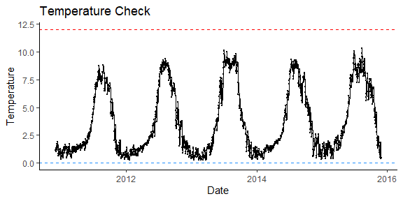

```r
# visually check data
plot_check_temp(
  data = crooked_river,
  dates = date,
  temperature = temp_c,
  temp_min = 0,
  temp_max = 12
)
```

We can use the functionality of **dplyr** to do a data check that shows the number of observations per year:

```r
crooked_river |>
  mutate(year = lubridate::year(date)) |>
  group_by(year) |>
  tally()
```

```
#> # A tibble: 6 × 2
#>    year     n
#>   <dbl> <int>
#> 1  2010    31
#> 2  2011   365
#> 3  2012   366
#> 4  2013   365
#> 5  2014   365
#> # ℹ 1 more row
```

Remember, our data starts just barely in 2010, so our spawning years would be 2011-2015. However we may not have enough days of record to make predictions for 2015 so best to check that first.

First let’s just check to see if fish spawning in 2015 would have enough data to hatch and emerge.

```r
# select bull trout hatch and emergence models
bull_hatch_mod <- model_select(
  author = "Austin et al. 2019",
  species = "bull trout",
  model = "MM",
  development_type = "hatch" # note we are using hatch model here
)

bull_emerge_mod <- model_select(
  author = "Austin et al. 2019",
  species = "bull trout",
  model = "MM",
  development_type = "emerge" # note we are using emerge model here
)

# set spawning dates in 2015
dates_2015 <- c("2015-09-01", "2015-09-15", "2015-09-30")

## hatch first
hatch_2015 <- dates_2015 |> purrr::map(
  predict_phenology,
  data = crooked_river,
  dates = date,
  temperature = temp_c,
  model = bull_hatch_mod
)
```

See how we receive 2 separate warning messages saying: “Fish did not accrue enough effective units to develop. Did your fish spawn too close to the end of your data? Spawn date is _____”. It tells us the spawn date we used so we can reference which date isn’t working if we use an string of multiple dates to predict over.

If fish aren’t hatching they definitely are not going to emerge, so we won’t use 2015.

### Looping

We will build a nested loop to automate over model selection variables and then over the dates. So the order of applying the `predict_phenology()` function in the loop example below is as follows:

- Predict hatch
  - 2011 spawn dates
  - …
  - 2014 spawn dates
- Predict emergence
  - 2011 spawn dates
  - …
  - 2014 spawn dates

```r
## mini loop to make vector of dates
spawn_dates <- NULL
for (year in 2011:2014) {
  temp_dates <- c(paste0(year, "-09-01"), paste0(year, "-09-15"), paste0(year, "-09-30"))
  spawn_dates <- c(spawn_dates, temp_dates)
}
spawn_dates
```

```
#>  [1] "2011-09-01" "2011-09-15" "2011-09-30" "2012-09-01" "2012-09-15"
#>  [6] "2012-09-30" "2013-09-01" "2013-09-15" "2013-09-30" "2014-09-01"
#> [11] "2014-09-15" "2014-09-30"
```

```r
### loop for prediction
OUT <- NULL
i <- 1 # build a counter for adding to our list of lists (OUT)

for (mod in c("hatch", "emerge")) { # loop for hatch and emerge

  # here we just iterate model selection over the two hatch and emerge options
  # in the first for loop
  dev_mod <- model_select(
    author = "Austin et al. 2019",
    species = "bull trout",
    model = "MM",
    development_type = mod
  )

  for (d in 1:length(spawn_dates)) { # nested loop over spawn dates

    # here we iterate over every date of spawn_dates but run this loop twice,
    # once for each value of the first for loop

    spawn <- spawn_dates[d] # get spawn date

    temp <- predict_phenology(
      data = crooked_river,
      dates = date,
      temperature = temp_c,
      spawn.date = spawn,
      model = dev_mod
    ) # notice we are calling the mod we set in the fist loop

    OUT[[i]] <- temp

    i <- i + 1 # add to your counter
  }
}
```

The output of this loop is again a list of lists. This time 24 lists that comprise the elements of each `predict_phenology()` iteration. Simply, the loop selects the hatch model, runs it for every date in our vector (`spawn_dates`) and then switches over to an emerge model and does the same thing. The point of having an iterator (`i`) is that we can make a new list addition to `OUT` for every combination of the `dev_mod` (hatch and emerge) and the 12 dates we want to run—resulting in 24 total individual lists that are appended to our `OUT` list of lists as we walk through each iteration of the for loop.

If that sounds a bit complicated, it’s because it is. And this is where the vectorized approaches really shine.

A quick note about accessing lists. Even if you want to write loops instead of vectorizing, we do recommend accessing those results via a vectorized approach. It’s hard to pull out a lot of information from very large nested loops. You would probably write a custom loop to do so. However, those results are easily accessed by map, like so:

```r
mapped_results <- OUT |> purrr:::map_df("ef_table")
mapped_results
```

```
#> # A tibble: 3,621 × 5
#>   index dates               temperature ef_vals ef_cumsum
#>   <dbl> <dttm>                    <dbl>   <dbl>     <dbl>
#> 1   275 2011-09-01 00:00:00        6.65  0.0148    0.0148
#> 2   276 2011-09-02 00:00:00        6.45  0.0144    0.0292
#> 3   277 2011-09-03 00:00:00        6.46  0.0144    0.0436
#> 4   278 2011-09-04 00:00:00        6.66  0.0148    0.0584
#> 5   279 2011-09-05 00:00:00        6.88  0.0152    0.0736
#> # ℹ 3,616 more rows
```

The above code outputs the `ef_table` element from every one of your lists from each combination of spawn date and phenology type into a dataframe like object which can then easily be plotted. Notice, we now use `purrr::map_df()` because we know the list element we are accessing is in the format of a dataframe type object (a tibble).